# Introduction to Biostatistical Computing PHC 6937

Basic statistical inference in R

Zhiguang Huo (Caleb)

Wednesday Oct 12th, 2022

# Outlines

- Simulating random variables
- Basic hypothesis testing
- linear regression model

# Random samples from a given pool of numbers

```r
a <- 1:10
sample(x = a, size = 2)
```

```
## [1] 4 6
```

```r
sample(x = a, size = 2)
```

```
## [1] 3 7
```

```r
sample(x = a, size = 2)
```

```
## [1] 10  5
```

# Are they really random? Can generate the same random number (for reproducibility)?

- The random numbers generated in R are not truly random, they are **pseudorandom**.
- So we are able to reproduce the exact same random numbers by setting random seeds.

```r
a <- 1:10
set.seed(32611) ## 32611 can be replaced by any number
sample(x = a, size = 2)
```

```
## [1] 1 7
```

```r
set.seed(32611) ## if you keep the same random seed, you will end up with the exact same result
sample(x = a, size = 2)
```

```
## [1] 1 7
```

```r
set.seed(32611) ## if you keep the same random seed, you will end up with the exact same result
sample(x = a, size = 2)
```

```
## [1] 1 7
```

# Each time the seed is set, the same sequence follows

```r
set.seed(32611)
sample(1:10,2); sample(1:10,2); sample(1:10,2)
```

```
## [1] 1 7
```

```
## [1] 3 7
```

```
## [1] 8 5
```

```r
set.seed(32611)
sample(1:10,2); sample(1:10,2); sample(1:10,2)
```

```
## [1] 1 7
```

```
## [1] 3 7
```

```
## [1] 8 5
```

# However, R version may impact the random number

```r
set.seed(32611)
sample(1:10,2)
```

```
## [1] 1 7
```

# Want to sample from a given pool of numbers with replacement

```r
sample(1:10) ## default is without replacement
```

```
##  [1]  3  7  9  5  8  1  2  4  6 10
```

```r
sample(1:10, replace = T) ## with replacement
```

```
##  [1] 3 8 9 7 2 6 5 5 7 3
```

```r
sample(LETTERS[1:10], replace = T) ## with replacement
```

```
##  [1] "G" "C" "A" "J" "G" "I" "I" "B" "D" "H"
```

# Random number generation from normal distribution

For normal distribution:

- rnorm(): generate random variable from normal distribution
- pnorm(): get CDF/pvalue from normal distribution, $\Phi(x) = P(Z \le x)$
- dnorm(): normal density function $\phi = \Phi'(x)$
- qnorm(): quantile function for normal distribution $q(y) = \Phi^{-1}(y)$ such that $\Phi(q(y)) = y$

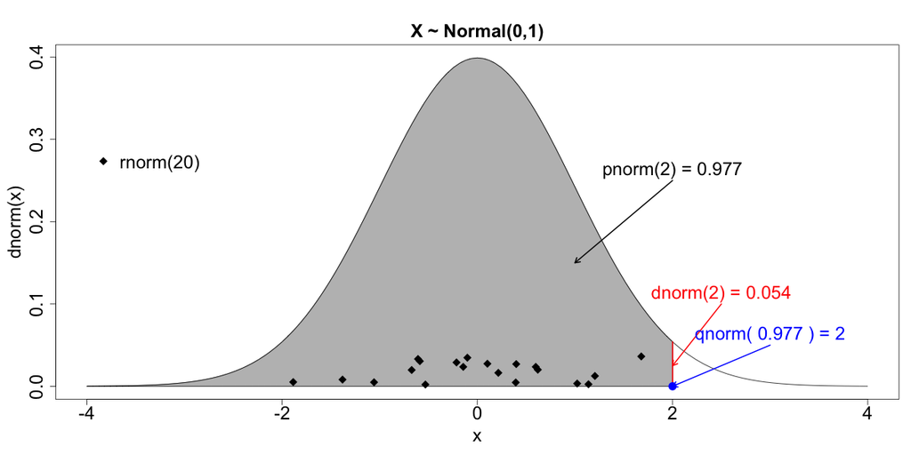

# Random variable simulators in R

| Distribution | R command |
| --- | --- |
| binomial | rbinom |
| Poisson | rpois |
| geometric | rgeom |
| negative binomial | rnbinom |
| uniform | runif |
| exponential | rexp |
| normal | rnorm |
| gamma | rgamma |
| beta | rbeta |
| student t | rt |
| F | rf |
| chi-squared | rchisq |
| Weibull | rweibull |
| log normal | rlnorm |

# Random variable density in R

| Distribution | R command |
| --- | --- |
| binomial | dbinom |
| Poisson | dpois |
| geometric | dgeom |
| negative binomial | dnbinom |
| uniform | dunif |
| exponential | dexp |
| normal | dnorm |
| gamma | dgamma |
| beta | dbeta |
| student t | dt |
| F | df |
| chi-squared | dchisq |
| Weibull | dweibull |
| log normal | dlnorm |

# Random variable distribution tail probablity in R

| Distribution | R command |
| --- | --- |
| binomial | pbinom |
| Poisson | ppois |
| geometric | pgeom |
| negative binomial | pnbinom |
| uniform | punif |
| exponential | pexp |
| normal | pnorm |
| gamma | pgamma |
| beta | pbeta |
| student t | pt |
| F | pf |
| chi-squared | pchisq |
| Weibull | pweibull |
| log normal | plnorm |

# Random variable distribution quantile in R

| Distribution | R command |
| --- | --- |
| binomial | qbinom |
| Poisson | qpois |
| geometric | qgeom |
| negative binomial | qnbinom |
| uniform | qunif |
| exponential | qexp |
| normal | qnorm |
| gamma | qgamma |
| beta | qbeta |
| student t | qt |
| F | qf |
| chi-squared | qchisq |
| Weibull | qweibull |
| log normal | qlnorm |

# Normal distribution

$$f(x;\mu,\sigma) = \frac{1}{\sqrt{2\pi \sigma^2}} e^{-\frac{(x-\mu)^2}{2\sigma^2}}$$

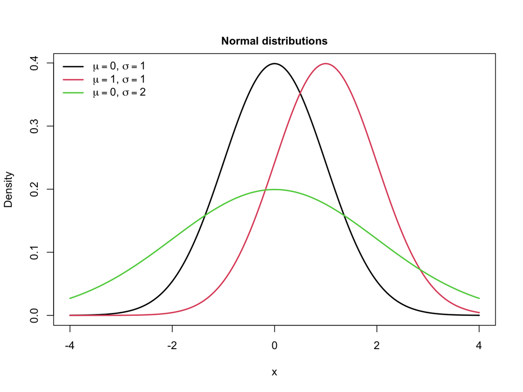

```r
aseq <- seq(-4,4,.01)
plot(aseq,dnorm(aseq, 0, 1),type='l', xlab='x', ylab='Density', lwd=2)
lines(aseq,dnorm(aseq, 1, 1),col=2, lwd=2)
lines(aseq,dnorm(aseq,0, 2),col=3, lwd=2)
legend("topleft",c(expression(paste(mu==0, ", " ,  sigma==1 ,sep=' ')),
             expression(paste(mu==1, ", " ,  sigma==1 ,sep=' ')),
             expression(paste(mu==0, ", " ,  sigma==2 ,sep=' '))),
       col=1:3, lty=c(1,1,1), lwd=c(2,2,2), cex=1, bty='n')
mtext(side=3,line=.5,'Normal distributions',cex=1, font=2)
```

# t distribution

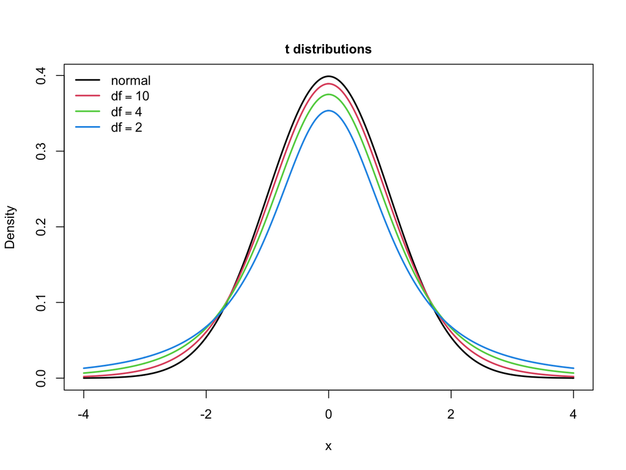

```r
aseq <- seq(-4,4,.01)
plot(aseq,dnorm(aseq),type='l', xlab='x', ylab='Density', lwd=2) ## same as dt(aseq, Inf)
lines(aseq,dt(aseq,10),col=2, lwd=2)
lines(aseq,dt(aseq,4),col=3, lwd=2)
lines(aseq,dt(aseq,2),col=4, lwd=2)
legend("topleft",c(expression(normal), expression(paste(df==10,sep=' ')),
             expression(paste(df==4,sep=' ')),
             expression(paste(df==2,sep=' '))),
       col=1:4, lty=c(1,1,1), lwd=c(2,2,2), cex=1, bty='n')
mtext(side=3,line=.5,'t distributions',cex=1, font=2)
```

# Chi-square distribution

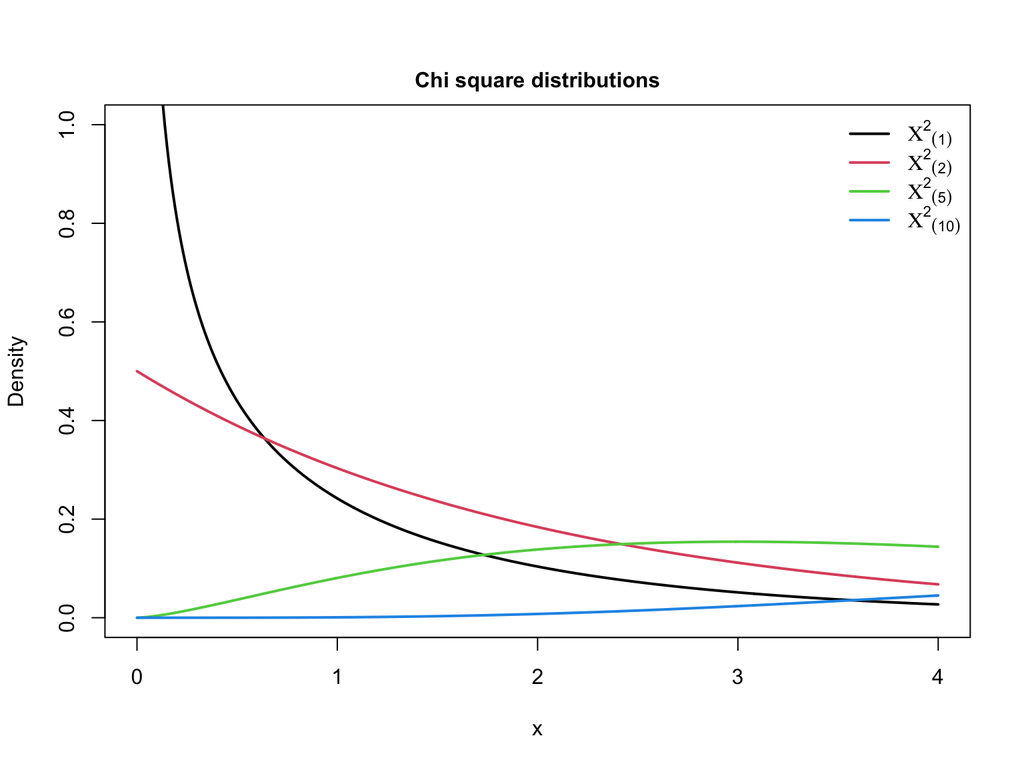

```r
aseq <- seq(0,4,.01)
plot(aseq,dchisq(aseq, df = 1),type='l', xlab='x', ylab='Density', lwd=2, ylim = c(0,1))
lines(aseq,dchisq(aseq,df = 2),col=2, lwd=2)
lines(aseq,dchisq(aseq,df = 5),col=3, lwd=2)
lines(aseq,dchisq(aseq,df = 10),col=4, lwd=2)
legend("topright",c(expression({Chi^2}[(1)]), expression({Chi^2}[(2)]),
             expression({Chi^2}[(5)]),
             expression({Chi^2}[(10)])
             ),
       col=1:4, lty=c(1,1,1), lwd=c(2,2,2), cex=1, bty='n')
mtext(side=3,line=.5,'Chi square distributions',cex=1, font=2)
```

# Chi-square distribution

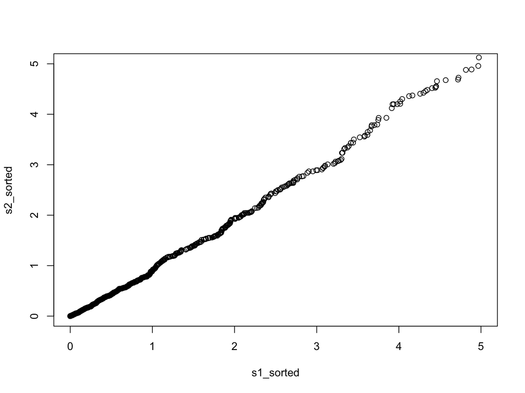

```r
## verification via qq-plot
set.seed(32608)
n <- 1000
x1 <- rnorm(n)
x2 <- rchisq(n,df = 1)
## the best practice is to use the theoretical distribution
## for simplicity, we can also use the emperical distribution

s1_sorted <- sort(x1^2)
s2_sorted <- sort(x2)

plot(s1_sorted, s2_sorted, xlim = c(0,5), ylim = c(0,5))
```

# Poisson distribution

$$f(k;\lambda) = \frac{\lambda^k e^{-\lambda}}{k!},$$
where $k$ is non negative integer.

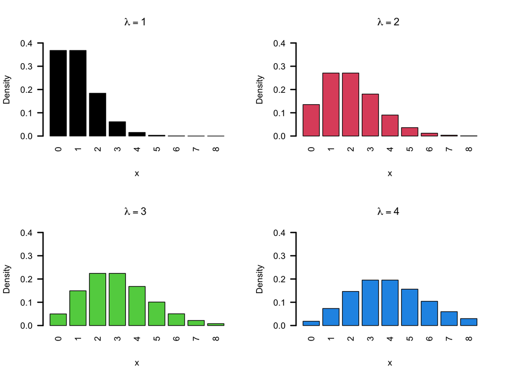

```r
aseq <- seq(0,8,1)
par(mfrow=c(2,2))
for(i in 1:4){
  counts <- dpois(aseq,i)
  names(counts) <- aseq
  barplot(counts, xlab='x', ylab='Density', lwd=2, col=i, las = 2,  main=bquote(paste(lambda==.(i), sep=' ')), ylim=c(0, 0.4))
}
```

# Beta distribution

$$f(x;\alpha,\beta) = \frac{\Gamma(\alpha + \beta)}{\Gamma(\alpha) \Gamma(\beta)} x^{\alpha - 1}(1 - x)^{\beta - 1}$$

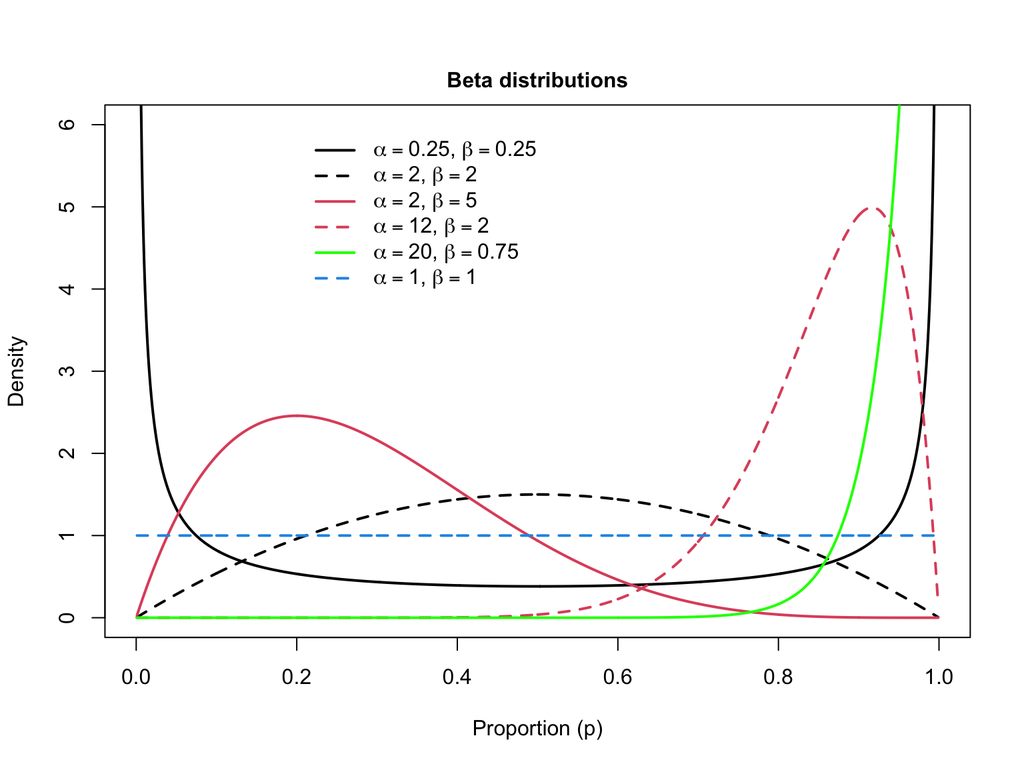

```r
aseq <- seq(.001,.999,.001)
plot(aseq,dbeta(aseq,.25,.25), type='l', ylim=c(0,6), ylab='Density', xlab='Proportion (p)',lwd=2)
lines(aseq, dbeta(aseq,2,2),lty=2,lwd=2)
lines(aseq, dbeta(aseq,2,5),lty=1,col=2,lwd=2)
lines(aseq, dbeta(aseq,12,2),lty=2,col=2,lwd=2)
lines(aseq, dbeta(aseq,20,.75),lty=1,col='green',lwd=2)
lines(aseq, dbeta(aseq,1,1),lty=2,lwd=2, col=4)
legend(.2,6,c(expression(paste(alpha==.25,', ', beta==.25)), expression(paste(alpha==2,', ',beta==2)), expression(paste(alpha==2,', ', beta==5)), expression(paste(alpha==12,', ',beta==2)), expression(paste(alpha==20,', ',beta==.75)), expression(paste(alpha==1,', ', beta==1))), lty=c(1,2,1,2,1,2), col=c(1,1,2,2,'green',4), cex=1,bty='n',lwd=rep(2,6))
mtext(side=3,line=.5,'Beta distributions',cex=1, font=2)
```

# Beta distribution

- $x \sim \mbox{Beta}(\alpha, \beta)$
- $f(x;\alpha,\beta) = \frac{\Gamma(\alpha + \beta)}{\Gamma(\alpha) \Gamma(\beta)} x^{\alpha - 1}(1 - x)^{\beta - 1}$
- $E(x) = \frac{\alpha}{\alpha + \beta}$
- when $\alpha = \beta = 1$, Beta distribution reduces to UNIF(0, 1)

# samples from Normal distribution

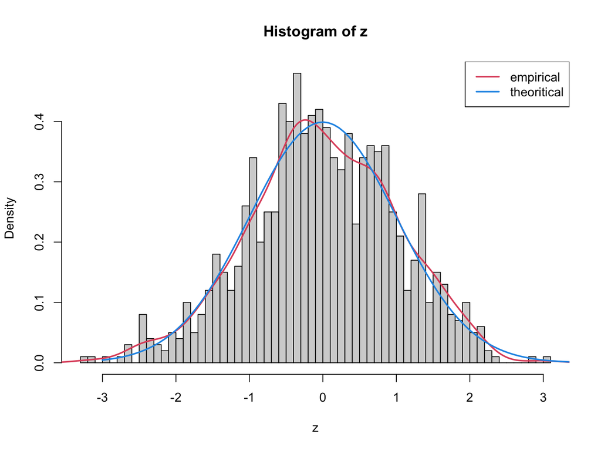

```r
set.seed(32608)
z <- rnorm(1000)
hist(z,nclass=50, freq = F)
lines(density(z), col=2, lwd=2)
curve(dnorm, from = -3, to = 4 ,col=4, lwd=2, add = T)
legend("topright", c("empirical", "theoritical"), col=c(2,4), lwd=c(2,2))
```

# Check CDF

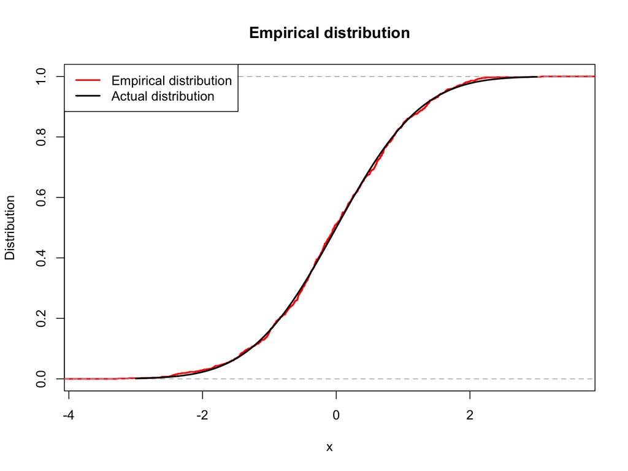

```r
set.seed(32608)
z <- rnorm(1000)
plot(ecdf(z), ylab="Distribution", main="Empirical distribution",
     lwd=2, col="red")
curve(pnorm, from = -3, to = 3, lwd=2, add = T)
legend("topleft", legend=c("Empirical distribution", "Actual distribution"),
       lwd=2, col=c("red","black"))
```

# p-value

- p-value:
  - When null hypothesis is true, the probability that the null statistics is as extreme or more extreme than the observed statistics.

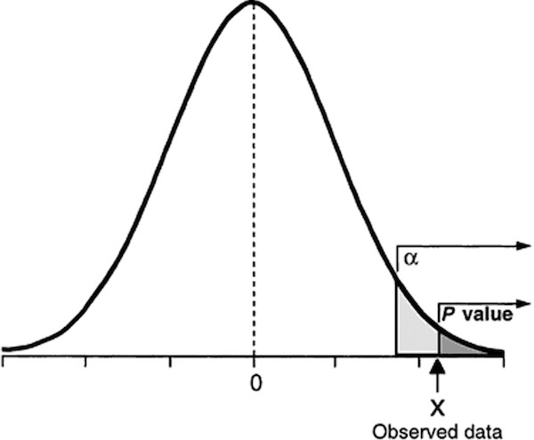

- p-value is the cumulative density, can be computed by pnorm() function

# p-value example

- E.g Null is $N(0,1)$, an observed statistics is 2.
  - one sided test, p-value is

  ```r
  pnorm(q = 2, mean = 0, sd = 1, lower.tail = FALSE) ## default: lower.tail = TRUE
  ```

  ```
  ## [1] 0.02275013
  ```

  - two sided test, p-value is

  ```r
  pnorm(q = 2, mean = 0, sd = 1, lower.tail = FALSE) + pnorm(q = - 2, mean = 0, sd = 1, lower.tail = TRUE)
  ```

  ```
  ## [1] 0.04550026
  ```

# quantile: qnorm()

- qnorm() calculates: given the area under the density curve (cumulative density), what is the quantile to generate such cumulative density?

```r
qnorm(p = 0.975, mean = 0, sd = 1, lower.tail = TRUE)
```

```
## [1] 1.959964
```

```r
qnorm(p = 0.025, mean = 0, sd = 1, lower.tail = TRUE)
```

```
## [1] -1.959964
```

- this is why 1.96 corresponds to 95% confidence interval.

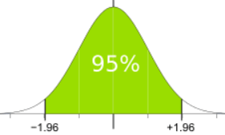

# Commonly used statistical tests

- t.test
- wilcox rank test
- chi square test
- Fisher’s exact test
- correlation test
- KS test

# Two sample t.test

- To compare the mean values of two samples that are normally distributed.
- Null hypothesis: mean values of two samples are the same.

```r
set.seed(32611)
a <- rnorm(10,0,1)
b <- rnorm(10,1,1)
t.test(a,b)
```

```
##
##  Welch Two Sample t-test
##
## data:  a and b
## t = -3.3236, df = 17.48, p-value = 0.0039
## alternative hypothesis: true difference in means is not equal to 0
## 95 percent confidence interval:
##  -2.2295315 -0.5002657
## sample estimates:
##  mean of x  mean of y
## -0.1733548  1.1915438
```

# Two sample paired t.test

- Used when your data are in matched pairs
- Null hypothesis: mean values of two samples are the same.

```r
set.seed(32611)
a <- rnorm(10,0,1)
b <- rnorm(10,1,1)
t.test(a,b,paired=TRUE)
```

```
##
##  Paired t-test
##
## data:  a and b
## t = -2.5027, df = 9, p-value = 0.03371
## alternative hypothesis: true difference in means is not equal to 0
## 95 percent confidence interval:
##  -2.5985937 -0.1312035
## sample estimates:
## mean of the differences
##               -1.364899
```

# One sample t.test

- To test if the group mean is different from 0
- Null hypothesis: mean value of a group is 0.

```r
set.seed(32611)
a <- rnorm(10,0,1)
t.test(a)
```

```
##
##  One Sample t-test
##
## data:  a
## t = -0.65621, df = 9, p-value = 0.5281
## alternative hypothesis: true mean is not equal to 0
## 95 percent confidence interval:
##  -0.7709621  0.4242526
## sample estimates:
##  mean of x
## -0.1733548
```

# Two sample Wilcox Rank Sum test

- To compare the median values of two samples without any distribution assumption.
- non-parametric test
- Null hypothesis: median values of two samples are the same.

```r
set.seed(32611)
a <- rnorm(10,0,1)
b <- rnorm(10,1,1)
wilcox.test(a,b)
```

```
##
##  Wilcoxon rank sum exact test
##
## data:  a and b
## W = 13, p-value = 0.003886
## alternative hypothesis: true location shift is not equal to 0
```

# Two sample paired Wilcox Rank Sum test

- Used when your data are in matched pairs
- Null hypothesis: median values of two samples are the same.

```r
set.seed(32611)
a <- rnorm(10,0,1)
b <- rnorm(10,1,1)
wilcox.test(a,b, paired = TRUE)
```

```
##
##  Wilcoxon signed rank exact test
##
## data:  a and b
## V = 5, p-value = 0.01953
## alternative hypothesis: true location shift is not equal to 0
```

# Chi square test

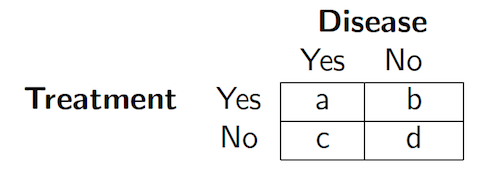

- test for independence
  - Null hypothesis: the treatment effects are the same between treatment and placebo groups.
- Consider the following data that describes the relationship between myocardial infarction and aspirin use (Agresti 1996).

```r
X <- matrix(c(189, 104, 10845, 10933), nrow=2,
            dimnames=list(Treatment=c("Placebo","Aspirin"),
                          "Myocardial Infarction"=c("Yes", "No")))
```

# Chi square test

- all of the expected numbers should be greater than 5
- Can also be applied to tables with more than 2 categories.
- Null hypothesis: the treatment effects are the same between treatment and placebo groups.

```r
X
```

```
##          Myocardial Infarction
## Treatment Yes    No
##   Placebo 189 10845
##   Aspirin 104 10933
```

```r
chisq.test(X)
```

```
##
##  Pearson's Chi-squared test with Yates' continuity correction
##
## data:  X
## X-squared = 24.429, df = 1, p-value = 7.71e-07
```

# Fisher’s exact test

- Also test for independence
- No approximation.
- Null hypothesis: the treatment effects are the same between treatment and placebo groups.

```r
X
```

```
##          Myocardial Infarction
## Treatment Yes    No
##   Placebo 189 10845
##   Aspirin 104 10933
```

```r
fisher.test(X)
```

```
##
##  Fisher's Exact Test for Count Data
##
## data:  X
## p-value = 5.033e-07
## alternative hypothesis: true odds ratio is not equal to 1
## 95 percent confidence interval:
##  1.432396 2.353927
## sample estimates:
## odds ratio
##   1.831993
```

# correlation test

- Null hypothesis: there is no correlation between vector a and b.

```r
set.seed(32611)
a <- rnorm(10,0,1)
b <- rnorm(10,1,1)

cor.test(a,b) ## parametric test: Gaussian assumption
```

```
##
##  Pearson's product-moment correlation
##
## data:  a and b
## t = -3.4699, df = 8, p-value = 0.008444
## alternative hypothesis: true correlation is not equal to 0
## 95 percent confidence interval:
##  -0.9440264 -0.2841809
## sample estimates:
##        cor
## -0.7751172
```

```r
cor.test(a,b, method = "spearman") ## non-parametric test: no distribution assumption
```

```
##
##  Spearman's rank correlation rho
##
## data:  a and b
## S = 292, p-value = 0.01367
## alternative hypothesis: true rho is not equal to 0
## sample estimates:
##       rho
## -0.769697
```

# KS test

- Kolmogorov-Smirnov test: Do x and y come from the same distribution?
- Null hypothesis: x and y come from the same distribution.

```r
set.seed(32611)
x <- rnorm(50,0,1)
y <- rnorm(50,1,1)
ks.test(x,y)
```

```
##
##  Two-sample Kolmogorov-Smirnov test
##
## data:  x and y
## D = 0.38, p-value = 0.001315
## alternative hypothesis: two-sided
```

[output not shown]

# Fit linear model in R, lm()

Basic syntax for lm()

```r
lm(formula, data)
```

- formula: Symbolic description of the model
- data: Optional dataframe containing the variables in the model
- summary() function summarize the linear model result

```r
lmfit <- lm(mpg ~ cyl, data=mtcars)
lmfit
```

```
##
## Call:
## lm(formula = mpg ~ cyl, data = mtcars)
##
## Coefficients:
## (Intercept)          cyl
##      37.885       -2.876
```

```r
summary(lmfit)
```

```
##
## Call:
## lm(formula = mpg ~ cyl, data = mtcars)
##
## Residuals:
##     Min      1Q  Median      3Q     Max
## -4.9814 -2.1185  0.2217  1.0717  7.5186
##
## Coefficients:
##             Estimate Std. Error t value Pr(>|t|)
## (Intercept)  37.8846     2.0738   18.27  < 2e-16 ***
## cyl          -2.8758     0.3224   -8.92 6.11e-10 ***
## ---
## Signif. codes:  0 '***' 0.001 '**' 0.01 '*' 0.05 '.' 0.1 ' ' 1
##
## Residual standard error: 3.206 on 30 degrees of freedom
## Multiple R-squared:  0.7262, Adjusted R-squared:  0.7171
## F-statistic: 79.56 on 1 and 30 DF,  p-value: 6.113e-10
```

- Interpretation:
  - Unit increase in cyl will result in 2.88 decrease in mpg.
  - p-value of cyl < 0.05 indicates cyl is a significant predictor.
- outcome variable: mpg
- predictors: cyl, disp

```r
lmfit <- lm(mpg ~ cyl + disp, data=mtcars)
summary(lmfit)
```

```
##
## Call:
## lm(formula = mpg ~ cyl + disp, data = mtcars)
##
## Residuals:
##     Min      1Q  Median      3Q     Max
## -4.4213 -2.1722 -0.6362  1.1899  7.0516
##
## Coefficients:
##             Estimate Std. Error t value Pr(>|t|)
## (Intercept) 34.66099    2.54700  13.609 4.02e-14 ***
## cyl         -1.58728    0.71184  -2.230   0.0337 *
## disp        -0.02058    0.01026  -2.007   0.0542 .
## ---
## Signif. codes:  0 '***' 0.001 '**' 0.01 '*' 0.05 '.' 0.1 ' ' 1
##
## Residual standard error: 3.055 on 29 degrees of freedom
## Multiple R-squared:  0.7596, Adjusted R-squared:  0.743
## F-statistic: 45.81 on 2 and 29 DF,  p-value: 1.058e-09
```

- outcome variable: mpg
- predictors: all the rest of the variables

```r
lmfit <- lm(mpg ~ ., data=mtcars)
summary(lmfit)
```

```
##
## Call:
## lm(formula = mpg ~ ., data = mtcars)
##
## Residuals:
##     Min      1Q  Median      3Q     Max
## -3.4506 -1.6044 -0.1196  1.2193  4.6271
##
## Coefficients:
##             Estimate Std. Error t value Pr(>|t|)
## (Intercept) 12.30337   18.71788   0.657   0.5181
## cyl         -0.11144    1.04502  -0.107   0.9161
## disp         0.01334    0.01786   0.747   0.4635
## hp          -0.02148    0.02177  -0.987   0.3350
## drat         0.78711    1.63537   0.481   0.6353
## wt          -3.71530    1.89441  -1.961   0.0633 .
## qsec         0.82104    0.73084   1.123   0.2739
## vs           0.31776    2.10451   0.151   0.8814
## am           2.52023    2.05665   1.225   0.2340
## gear         0.65541    1.49326   0.439   0.6652
## carb        -0.19942    0.82875  -0.241   0.8122
## ---
## Signif. codes:  0 '***' 0.001 '**' 0.01 '*' 0.05 '.' 0.1 ' ' 1
##
## Residual standard error: 2.65 on 21 degrees of freedom
## Multiple R-squared:  0.869,  Adjusted R-squared:  0.8066
## F-statistic: 13.93 on 10 and 21 DF,  p-value: 3.793e-07
```